## Decision Trees and Agregation Methods

[figure not shown]

**Classification trees** are used to predict the assignment of observations or objects to classes of a **categorical dependent variable** based on their measurements on one or more predictor variables. Decision trees are one of the main techniques used in data mining.

The goal of classification trees is to **predict or explain the responses of a categorical dependent variable**, which is why the techniques in this module are quite similar to the more traditional methods of **Discriminant Analysis** and **Nonlinear Estimation**. The flexibility of classification trees makes them a very attractive analytical option, but they should not completely replace more traditional methods.

## CART Algorithm

As the name suggests, **CART** (**C**lassification **A**nd **R**egression **T**rees) can be used for both classification and regression problems. Both cases fall under the **supervised branch of machine learning algorithms**. CART algorithm uses **Gini Index criterion to split a node to a sub-node**. It starts with the training set as a root note : after successfully splitting the root note in two, it splits the substes using the same logic and again split the sub-subsets, recursively until it finds further splitting will not give any pure sub-nodes or maximum number of leaves in a growing tree or termed it as a **Tree pruning**.

## Agregation Models

### Bagging

**Ensemble machine learning** can be mainly categorized into **bagging** and **boosting**. The bagging technique is used with decision trees, where it **significantly raises the stability of models in improving accuracy and reducing variance**, wich eliminates the challenge of overfitting. It consists in **aggregating a number B of estimators in parallel**. Bagging offers the advantage of **allowing many weak learners to combine efforts to outdo a single strong learner**. It also helps in the reduction of variance but introduces a loss of interpretability of a model. The main disadvantage is the computing time, which may discourage its use in certain instances.

### Random Forest

The **random forest** is a classification algorithm consisting of many decisions trees. It uses **bagging** and **feature randomness** when building each individual tree to try to create an **uncorrelated forest of trees whose prediction by committee is more accurate than that of any individual tree**. One big advantage of random forest is that it has no **hyper-paramer tuning**, and gives a great result most of the time. On the other hand, the biggest problems in machine learning is overfitting, but most of the time it won’t happen thanks to the random forest classifier. In fact, **if there are enough trees in the forest, the classifier won’t overfit the model**.

### Adaboost

**Adaboost algorithm**, short for **Adaptive Boosting**, is a Boosting technique used as an **Ensemble Method in Machine Learning**. It is called **Adaptive Boosting** as the **weighs are re-assigned to each instance, with higher weights assigned to incorrectly classified instances**. It works on the principle of learners growing **sequentially**. Except for the first, each subsequent learner is grown from previously grown learners. It makes n number of decision trees during the data training period. As the first model is made, the incorrectly classified record in the first model is given priority. Only these records are sent as input for the second model. The process goes on until we specify a number of learners we want to create.

The output of the final hypothesis from Adaboost is given by :

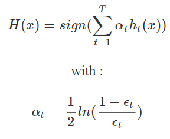

### Gradient Boosting

**Gradient boosting** is a type of **machine learning boosting**, like Adaboost algorithm. It relies on the intuition that **the best possible next model, when combined with previous models, minimizes the overall prediction error**. The key idea is to **set the target outcomes for this next model in order to minimize the error**. The name gradient boosting arises because **target outcomes for each case are set based on the gradient of the error with respect to the prediction**. Each new model takes a step in the direction that minimizes prediction error, in the space of possible predictions for each training case.

The output of the final hypothesis from Gradient Boosting is given by :

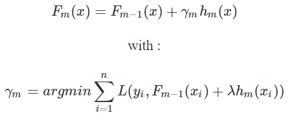